# Индивидуальный проект. Этап 3. Использование Hydra.

Презентация

Глушенок А. А.

Российский университет дружбы народов, Москва, Россия

3 апреля 2026

## Докладчик

- Глушенок Анна Александровна
- Студент НПИбд-01-24
- Факультет физико-математических и естественных наук
- Российский университет дружбы народов
- 1132246844@pfur.ru
- https://github.com/aaglushenok

## Цель

Осуществить запрос к Hydra, получить существующие пары логин-пароль, войти с помощью них на DWVA Brute Force.

# Выполнение этапа

## Задание 1

1. Копируем в терминал команду для запроса к Hydra (из материалов к выполнению 3 этапа проекта).

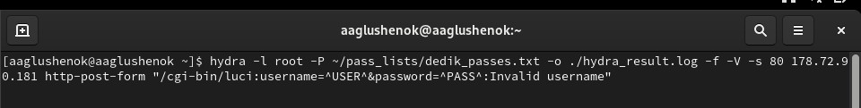

Figure 1: Задание 1

## Задание 2

2. Начинаем адаптировать команду под нужные параметры. Меняем логин с root на admin.

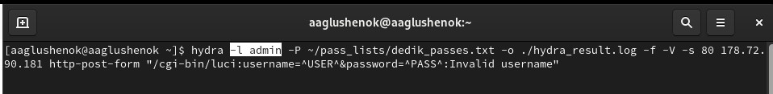

Figure 2: Задание 2

## Задание 3

3. Меняем словарь паролей на тот, который у нас скачан.

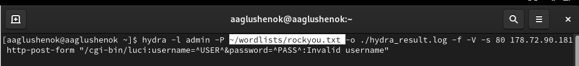

Figure 3: Задание 3

## Задание 4

4. Устанавливаем правильный порт, цель и прописываем метод GET.

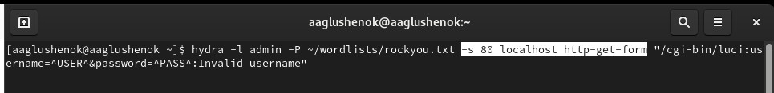

Figure 4: Задание 4

## Задание 5

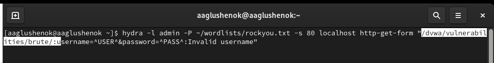

Figure 5: Задание 5

## Задание 6

6. Открываем в браузере DWVA, нажимаем ПКМ -> исследовать -> хранилище. Смотрим уровень безопасности (в моем случае low) и копируем идентификатор PHPSESSID.

[figure not shown]

Figure 6: Задание 6

## Задание 6

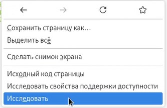

Figure 7: Задание 6

## Задание 6

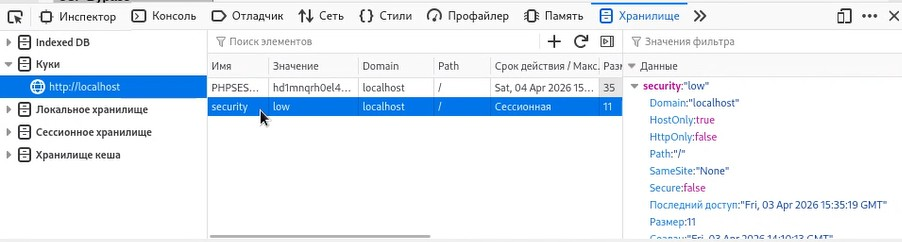

Figure 8: Задание 6

## Задание 7

7. Прописываем в команде уровень безопасности и идентификатор PHPSESSID.

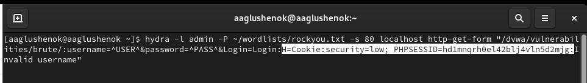

Figure 9: Задание 7

## Задание 8

8. Прописываем сообщения на случай неудачной попытки входа.

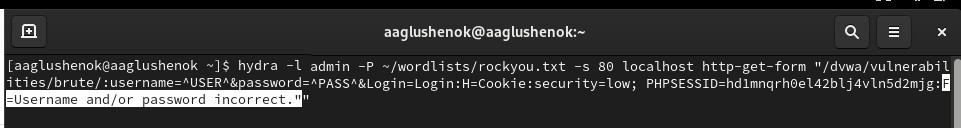

Figure 10: Задание 8

## Задание 9

9. Запускаем команду. В результате получаем единственную существующую пару логина и пароля (admin, password).

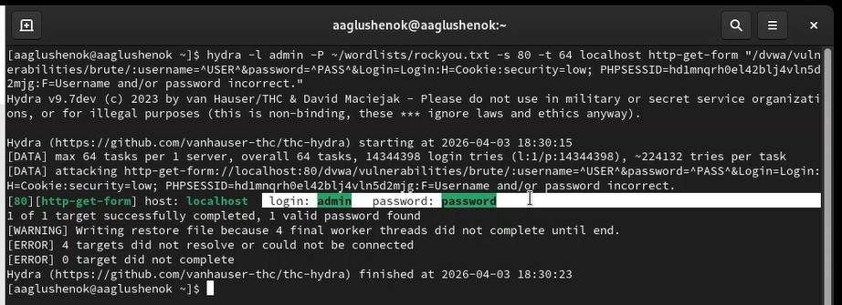

Figure 11: Задание 9

## Задание 10

10. Вводим полученные логин и пароль на странице DWVA Brute Force, получаем сообщение “добро пожаловать” (“Welcome to rthe password protected area admin”).

[figure not shown]

Figure 12: Задание 10

# Выводы

В ходе выполнения 3 этапа индивидуального проекта мне удалось осуществить запрос к Hydra, получить существующие пары логин-пароль, войти с помощью них на DWVA Brute Force.